# Topic 4 Exercises: Classification

## March 21, 2017

## Question 4.7.11

Part (a)

```r
library(MASS)
Auto <- read.csv("/home/local/MAC/dluc/Math-253-Assignment/Auto.csv", na.strings = "?")
Auto <- na.omit(Auto)
attach(Auto)

mpg01 <- ifelse(mpg > median(mpg),1,0)
Auto <- data.frame(Auto, mpg01)
```

Part (b)

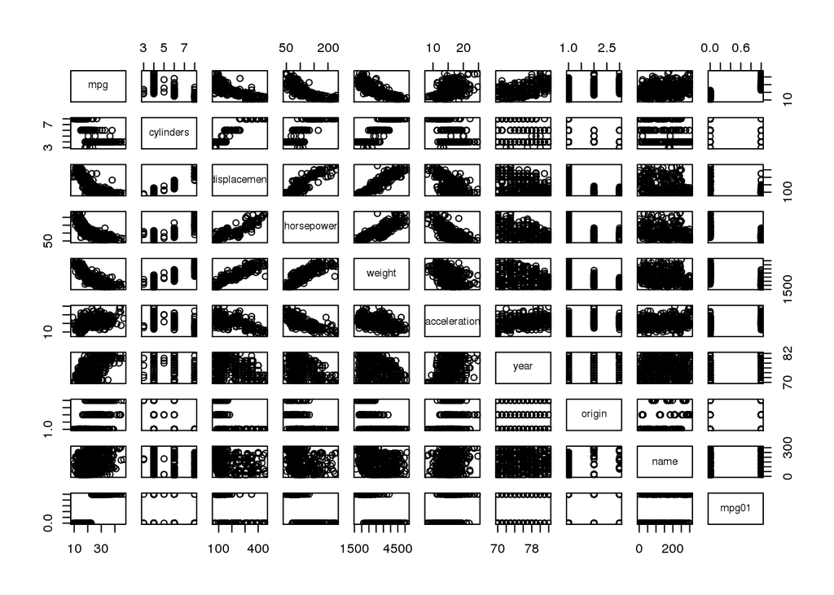

```r
pairs(Auto)
```

```r
cor(Auto[,-9])
```

```
##                     mpg  cylinders displacement horsepower     weight
## mpg           1.0000000 -0.7776175   -0.8051269 -0.7784268 -0.8322442
## cylinders    -0.7776175  1.0000000    0.9508233  0.8429834  0.8975273
## displacement -0.8051269  0.9508233    1.0000000  0.8972570  0.9329944
## horsepower   -0.7784268  0.8429834    0.8972570  1.0000000  0.8645377
## weight       -0.8322442  0.8975273    0.9329944  0.8645377  1.0000000
## acceleration  0.4233285 -0.5046834   -0.5438005 -0.6891955 -0.4168392
## year          0.5805410 -0.3456474   -0.3698552 -0.4163615 -0.3091199
## origin        0.5652088 -0.5689316   -0.6145351 -0.4551715 -0.5850054
## mpg01         0.8369392 -0.7591939   -0.7534766 -0.6670526 -0.7577566
##              acceleration       year     origin      mpg01
## mpg             0.4233285  0.5805410  0.5652088  0.8369392
## cylinders      -0.5046834 -0.3456474 -0.5689316 -0.7591939
## displacement   -0.5438005 -0.3698552 -0.6145351 -0.7534766
## horsepower     -0.6891955 -0.4163615 -0.4551715 -0.6670526
## weight         -0.4168392 -0.3091199 -0.5850054 -0.7577566
## acceleration    1.0000000  0.2903161  0.2127458  0.3468215
## year            0.2903161  1.0000000  0.1815277  0.4299042
## origin          0.2127458  0.1815277  1.0000000  0.5136984
## mpg01           0.3468215  0.4299042  0.5136984  1.0000000
```

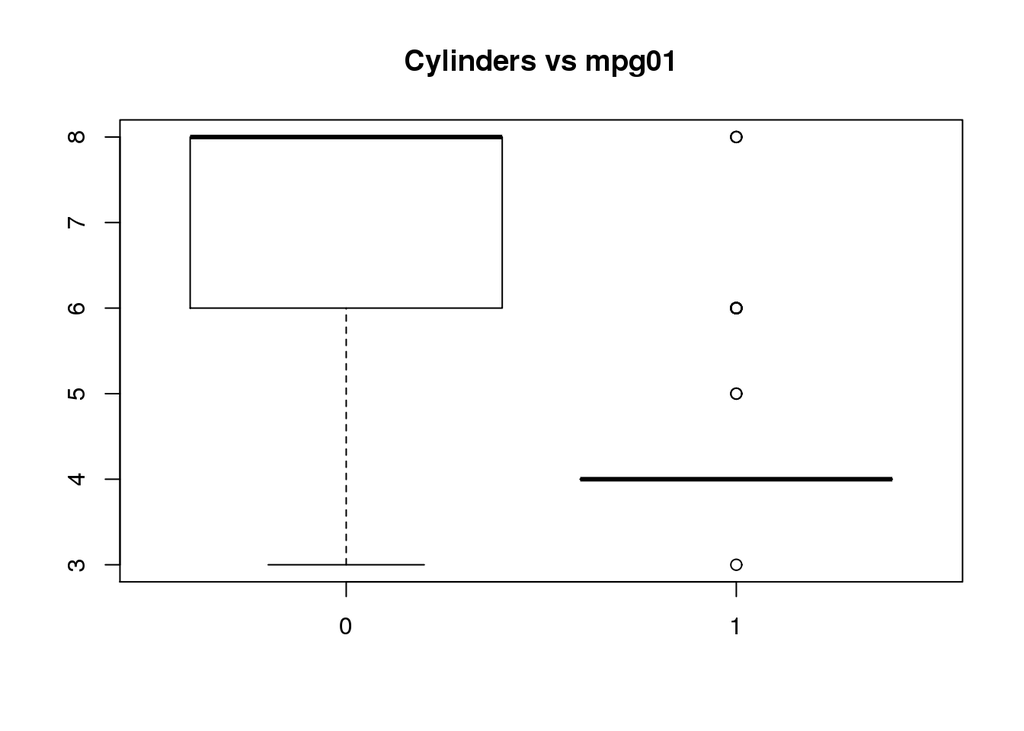

```r
box1 <- boxplot(cylinders ~ mpg01, data = Auto, main = "Cylinders vs mpg01")
```

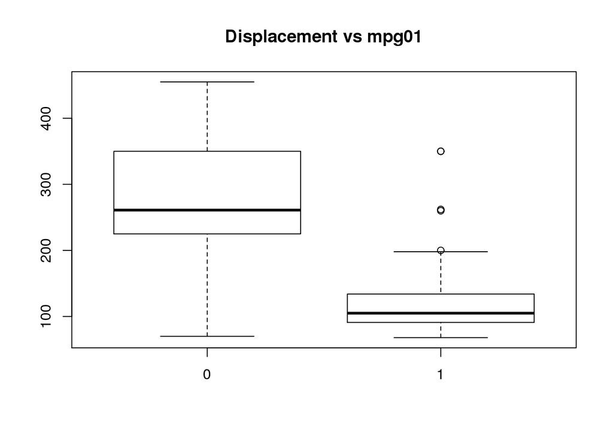

```r
box2 <- boxplot(displacement ~ mpg01, data = Auto, main = "Displacement vs mpg01")
```

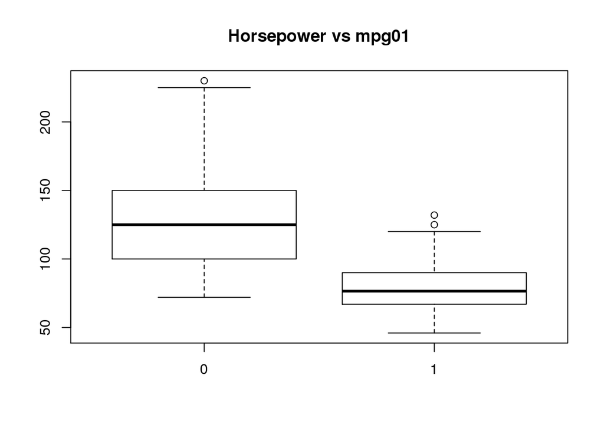

```r
box3 <- boxplot(horsepower ~ mpg01, data = Auto, main = "Horsepower vs mpg01")
```

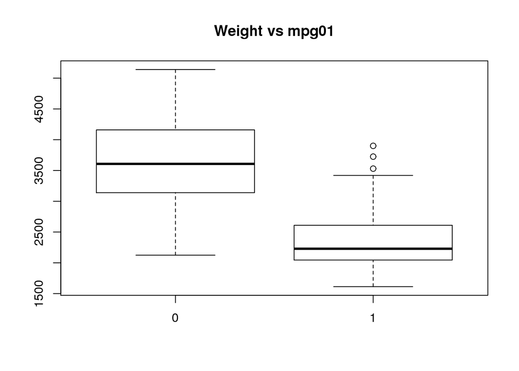

```r
box4 <- boxplot(weight ~ mpg01, data = Auto, main = "Weight vs mpg01")
```

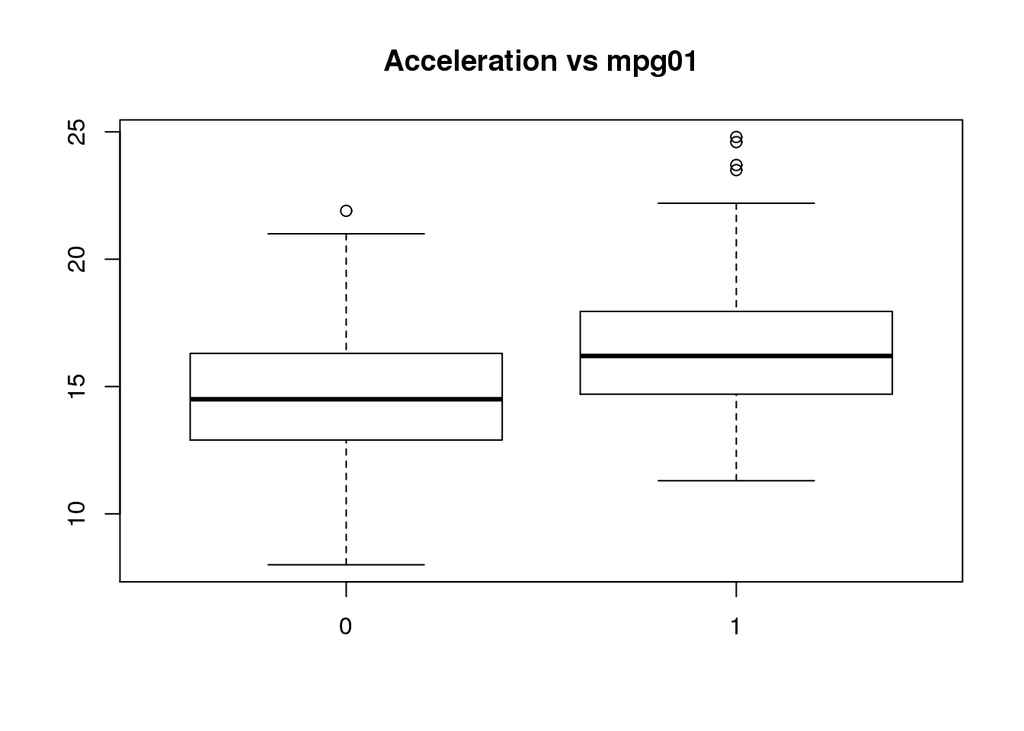

```r
box5 <- boxplot(acceleration ~ mpg01, data = Auto, main = "Acceleration vs mpg01")
```

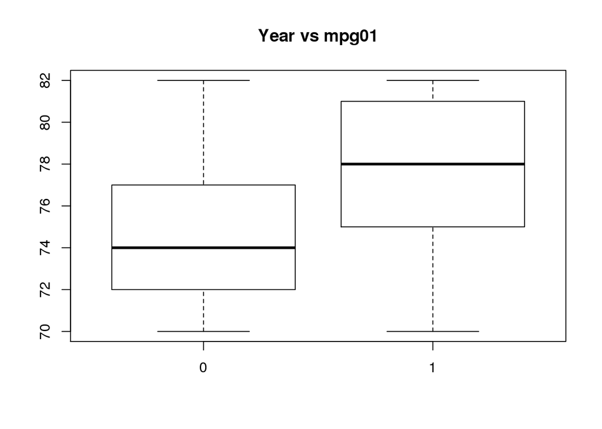

```r
box6 <- boxplot(year ~ mpg01, data = Auto, main = "Year vs mpg01")
```

Cylinders, displacement, horsepower, and weight look like they are most likely useful in predicting mpg01. They all are either correlated positively or negatively.

Part (c)

```r
train <- (year %% 2 == 0)
Auto.train <- Auto[train,]
Auto.test <- Auto[!train,]
mpg01.test <- mpg01[!train]
```

Part (d)

```r
mod1 <- lda(mpg01 ~ cylinders + displacement + horsepower + weight, data = Auto.train)
mod1
```

```
## Call:
## lda(mpg01 ~ cylinders + displacement + horsepower + weight, data = Auto.train)
##
## Prior probabilities of groups:
##         0         1
## 0.4571429 0.5428571
##
## Group means:
##   cylinders displacement horsepower   weight
## 0  6.812500     271.7396  133.14583 3604.823
## 1  4.070175     111.6623   77.92105 2314.763
##
## Coefficients of linear discriminants:
##                        LD1
## cylinders    -0.6741402638
## displacement  0.0004481325
## horsepower    0.0059035377
## weight       -0.0011465750
```

```r
pred1 <- predict(mod1, Auto.test)
table(pred1$class, mpg01.test)
```

```
##    mpg01.test
##      0  1
##   0 86  9
##   1 14 73
```

```r
mean(pred1$class != mpg01.test)
```

```
## [1] 0.1263736
```

We have a test error rate of 12.63736%.

Part (e)

```r
mod2 <- qda(mpg01 ~ cylinders + displacement + horsepower + weight, data = Auto.train)
mod2
```

```
## Call:
## qda(mpg01 ~ cylinders + displacement + horsepower + weight, data = Auto.train)
##
## Prior probabilities of groups:
##         0         1
## 0.4571429 0.5428571
##
## Group means:
##   cylinders displacement horsepower   weight
## 0  6.812500     271.7396  133.14583 3604.823
## 1  4.070175     111.6623   77.92105 2314.763
```

```r
pred2 <- predict(mod2, Auto.test)
table(pred2$class, mpg01.test)
```

```
##    mpg01.test
##      0  1
##   0 89 13
##   1 11 69
```

```r
mean(pred2$class != mpg01.test)
```

```
## [1] 0.1318681
```

We have a test error rate of 13.18681%.

Part (f)

```r
mod3 <- glm(mpg01 ~ cylinders + displacement + horsepower + weight, data = Auto.train, family = binomial)
summary(mod3)
```

```
##
## Call:
## glm(formula = mpg01 ~ cylinders + displacement + horsepower +
##     weight, family = binomial, data = Auto.train)
##
## Deviance Residuals:
##      Min        1Q    Median        3Q       Max
## -2.48027  -0.03413   0.10583   0.29634   2.57584
##
## Coefficients:
##               Estimate Std. Error z value Pr(>|z|)
## (Intercept)  17.658730   3.409012   5.180 2.22e-07 ***
## cylinders    -1.028032   0.653607  -1.573   0.1158
## displacement  0.002462   0.015030   0.164   0.8699
## horsepower   -0.050611   0.025209  -2.008   0.0447 *
## weight       -0.002922   0.001137  -2.569   0.0102 *
## ---
## Signif. codes:  0 '***' 0.001 '**' 0.01 '*' 0.05 '.' 0.1 ' ' 1
##
## (Dispersion parameter for binomial family taken to be 1)
##
##     Null deviance: 289.58  on 209  degrees of freedom
## Residual deviance:  83.24  on 205  degrees of freedom
## AIC: 93.24
##
## Number of Fisher Scoring iterations: 7
```

```r
pred3 <- predict(mod3, Auto.test, type = "response")
npred3 <- rep(0, length(pred3))
npred3[pred3 > 0.5] <- 1
table(npred3, mpg01.test)
```

```
##       mpg01.test
## npred3  0  1
##      0 89 11
##      1 11 71
```

```r
mean(npred3 != mpg01.test)
```

```
## [1] 0.1208791
```

The test error rate is 12.08791%.

Part (g)

```r
# train.Auto <-cbind(cylinders, displacement, horsepower,weight)[train,]
# test.Auto <-cbind(cylinders, displacement, horsepower,weight)[!train,]
# train.mpg01 <- mpg01[train]
#
# predknn <- knn(train.Auto, test.Auto, train.mpg01, k = 1)
# table(predknn, mpg01.test)
# mean(predknn, mpg01.test)
#
# predknn <- knn(train.Auto, test.Auto, train.mpg01, k = 1)
# table(predknn, mpg01.test)
# mean(predknn, mpg01.test)
#
# predknn <- knn(train.Auto, test.Auto, train.mpg01, k = 1)
# table(predknn, mpg01.test)
# mean(predknn, mpg01.test)
```

Part (g) does not work because it keeps saying unused argument for train.mpg01, but it defined in that same function box. So I don’t know what’s wrong since we couldn’t get knn to work in class either.

## Question 4.7.13

```r
attach(Boston)
crime <- rep(0, length(crim))
crime[crim > median(crim)] <- 1
Boston <- data.frame(Boston, crime)

train <- 1:(length(crim) / 2)
test <- (length(crim) / 2 + 1):length(crim)
Boston.train <- Boston[train, ]
Boston.test <- Boston[test, ]
crime.test <- crime[test]
```